# Templates for contributions to Computo

Author names  
2020-11-19

# Introduction

The goal of this package is to provide a template for contribution to the **Computo** Journal.

All submission should be made in Rmarkdown. Both `R` and `Python` are natively supported. You may use any other computer language (such as Julia) if you manage to render your Rmarkdown.

# Using python

The R package reticulate package includes a Python engine for R Markdown that enables easy interoperability between Python and R chunks. Below we demonstrate a small subset of the available functionalities. We refer to the vignette [R Markdown Python Engine](https://cran.r-project.org/web/packages/reticulate/vignettes/r_markdown.html) for a more detailed description.

```
library(reticulate)
use_virtualenv("computor-skeleton")
```

Firt make sure (here, in R) that the required python modules are available

```
py_module_available("seaborn") || py_install("seaborn")
py_module_available("pandas") || py_install("pandas")
py_module_available("matplotlib") || py_install("matplotlib")
```

Example of python code and associated output:

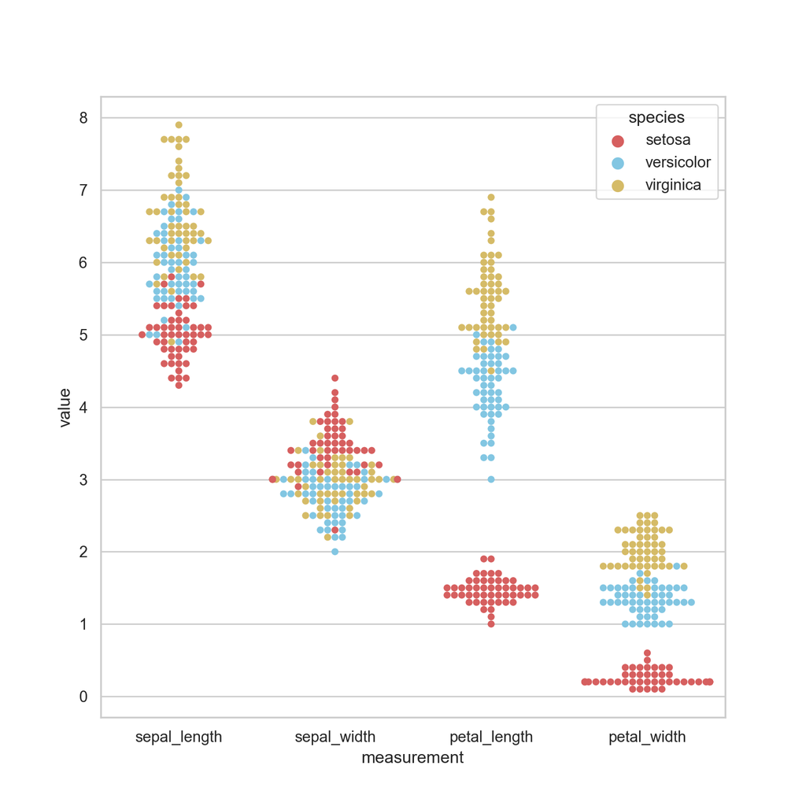

```python
import pandas as pd
import seaborn as sns
import matplotlib.pyplot as plt

sns.set(style="whitegrid", palette="muted")

# Load the example iris dataset
iris = sns.load_dataset("iris")

# "Melt" the dataset to "long-form" or "tidy" representation
iris = pd.melt(iris, "species", var_name="measurement")
plt.figure()

# Draw a categorical scatterplot to show each observation
sns.swarmplot(x="measurement", y="value", hue="species", palette=["r", "c", "y"], data=iris)
plt.show()
```

## Communication between R and python chunks

All objects created within Python chunks are available to R using the `py` object exported by the reticulate package, e.g.:

```
head(py$iris)
```

```
  species  measurement value
1  setosa sepal_length   5.1
2  setosa sepal_length   4.9
3  setosa sepal_length   4.7
4  setosa sepal_length   4.6
5  setosa sepal_length   5.0
6  setosa sepal_length   5.4
```

Conversely, all objects created within R are available to Pytho using the `r` object exported by the reticulate:

First, let us create an object within R:

```
data(volcano)
volcano[1:4, 1:4]
```

```
     [,1] [,2] [,3] [,4]
[1,]  100  100  101  101
[2,]  101  101  102  102
[3,]  102  102  103  103
[4,]  103  103  104  104
```

This object is accessible from Python:

```python
print(r.volcano)
```

```
[[100. 100. 101. ... 104. 104. 103.]
 [101. 101. 102. ... 105. 104. 104.]
 [102. 102. 103. ... 105. 105. 104.]
 ...
 [ 98.  98.  98. ...  94.  94.  94.]
 [ 97.  98.  98. ...  94.  94.  94.]
 [ 97.  97.  97. ...  94.  94.  94.]]
```

# References

References are displayed as margin notes. For example, we can cite R here (R Core Team 2020).

R Core Team. 2020. *R: A Language and Environment for Statistical Computing*. Vienna, Austria: R Foundation for Statistical Computing. https://www.R-project.org/.